# Etude de cas

#### Données

[`pendigits`](http://archive.ics.uci.edu/ml/datasets/pen-based+recognition+of+handwritten+digits) de l'UCI Machine Learning Repository

- Tracé des chiffres de 0 à 9 par plusieurs personnes
- Pour chaque tracé, coordonnées $(X, Y)$ de 8 points et le chiffre tracé

#### Objectifs

- Rechercher les différentes façons d'écrire chaque chiffre

#### Méthodes

- Importation et quelques manipulations
- Application de 2 méthodes (ACP et classification)

## Présentation des données

```python
print("Dimensions des données : ", pen.shape)
pen.head(10)
```

```
Dimensions des données :  (10992, 17)
```

|  | x1 | y1 | x2 | y2 | x3 | y3 | x4 | y4 | x5 | y5 | x6 | y6 | x7 | y7 | x8 | y8 | chiffre |
| --- | --- | --- | --- | --- | --- | --- | --- | --- | --- | --- | --- | --- | --- | --- | --- | --- | --- |
| 0 | 88 | 92 | 2 | 99 | 16 | 66 | 94 | 37 | 70 | 0 | 0 | 24 | 42 | 65 | 100 | 100 | 8 |
| 1 | 80 | 100 | 18 | 98 | 60 | 66 | 100 | 29 | 42 | 0 | 0 | 23 | 42 | 61 | 56 | 98 | 8 |
| 2 | 0 | 94 | 9 | 57 | 20 | 19 | 7 | 0 | 20 | 36 | 70 | 68 | 100 | 100 | 18 | 92 | 8 |
| 3 | 95 | 82 | 71 | 100 | 27 | 77 | 77 | 73 | 100 | 80 | 93 | 42 | 56 | 13 | 0 | 0 | 9 |
| 4 | 68 | 100 | 6 | 88 | 47 | 75 | 87 | 82 | 85 | 56 | 100 | 29 | 75 | 6 | 0 | 0 | 9 |
| 5 | 70 | 100 | 100 | 97 | 70 | 81 | 45 | 65 | 30 | 49 | 20 | 33 | 0 | 16 | 0 | 0 | 1 |
| 6 | 40 | 100 | 0 | 81 | 15 | 58 | 100 | 57 | 47 | 87 | 50 | 88 | 40 | 42 | 36 | 0 | 4 |
| 7 | 3 | 71 | 0 | 95 | 45 | 100 | 100 | 99 | 79 | 78 | 48 | 53 | 31 | 24 | 54 | 0 | 7 |
| 8 | 79 | 87 | 98 | 81 | 71 | 100 | 72 | 73 | 100 | 66 | 91 | 21 | 48 | 0 | 0 | 13 | 9 |
| 9 | 92 | 95 | 30 | 100 | 34 | 68 | 87 | 89 | 84 | 78 | 100 | 35 | 64 | 0 | 0 | 19 | 9 |

## Représentation du premier tracé de chaque chiffre

- Représenter chaque premier exemple de chaque chiffre

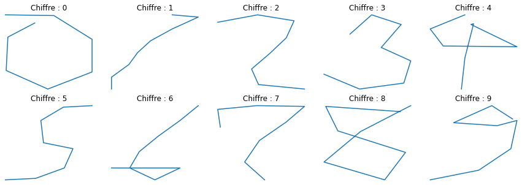

```python
sub_first_xyc = [[s.loc[0, xN], s.loc[0, yN], s.loc[0, "chiffre"]] for s in sub]
fig = plt.figure(figsize = (15, 5))
for i in range(10):
    ax = fig.add_subplot(2, 5, i + 1)
    dessin(ax, sub_first_xyc[i][0], sub_first_xyc[i][1], sub_first_xyc[i][2])
```

## Représentation des *chiffres moyens*

- Les chiffres 0, 1, 2, 3, 4, 6 semblent cohérents ;
- Le chiffre 8 paraît concentré sur la zone centrale ;
- Le chiffre 7, bien que presque reconnaissable, semble étonnant ;
- Les chiffres 5 et 9 sont difficilement reconnaissables.

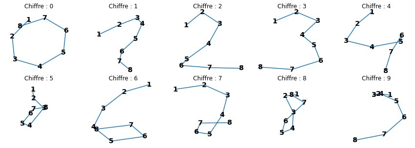

```python
fig = plt.figure(figsize = (15, 5))
for i in range(10):
    ax = fig.add_subplot(2, 5, i + 1)
    dessin(ax, cmoy.loc[i,xN], cmoy.loc[i,yN], str(i), pos = True)
```

## Représentation des tracés en 2D | sur données originales

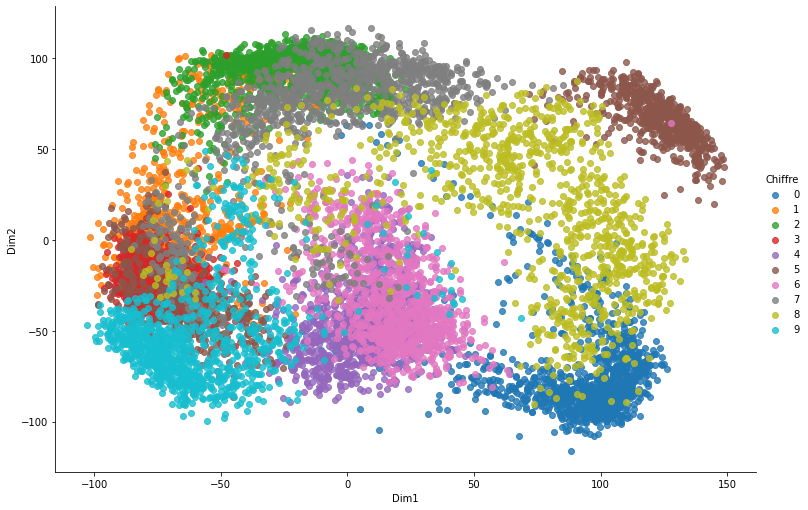

```python
seaborn.lmplot(data = pen_original_df, x = "Dim1", y = "Dim2", hue = "Chiffre",
              fit_reg = False, height = 7, aspect = 1.5)
plt.show()
```

## Représentation des tracés en 2D | sur données originales

- 2, 3, 4 et 6 : regroupés sur une zone restreinte ;
- 1, 5 (particulièrement), 7, 8 et 9 : avec groupes séparés ;
- 0 : forme allongée courbe.

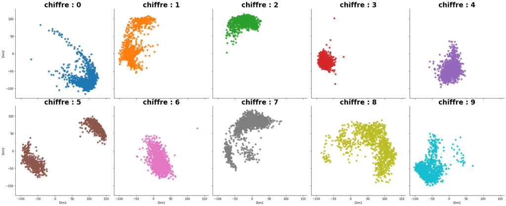

```python
g = seaborn.lmplot(data = pen_original_df, x = "Dim1", y = "Dim2", hue = "Chiffre",
               col = "Chiffre", col_wrap = 5, fit_reg = False)
g.set_titles(col_template = "chiffre : {col_name}", fontweight = "bold", size = 24)
plt.show()
```

## Représentation des tracés en 2D | sur données standardisées

- Forme sphérique due aux valeurs entre 0 et 100 d'une part, et à la standardisation d'autre part

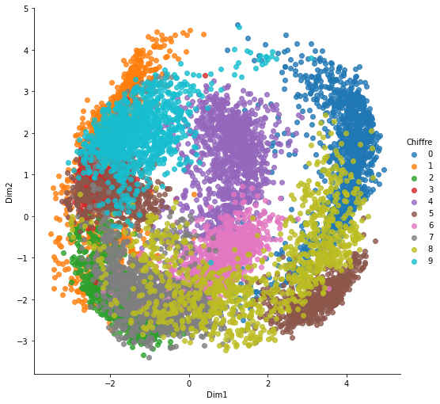

```python
seaborn.lmplot(data = pen_scale_df, x = "Dim1", y = "Dim2", hue = "Chiffre",
              fit_reg = False, height = 7, aspect = 1)
plt.show()
```

## Représentation des tracés en 2D | sur données standardisées

- 2, 3, 4 et 6 : aussi regroupés sur une zone restreinte ;
- 1, 5 (particulièrement), 7, 8 et 9 : encore des groupes séparés ;
- 0 : toujours une forme allongée courbe.

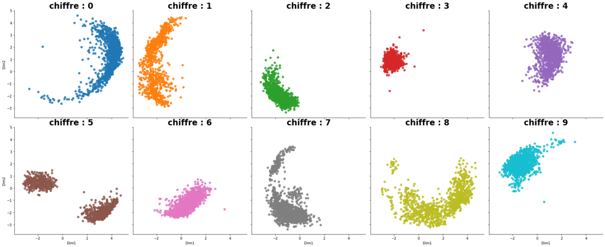

```python
g = seaborn.lmplot(data = pen_scale_df, x = "Dim1", y = "Dim2", hue = "Chiffre",
               col = "Chiffre", col_wrap = 5, fit_reg = False)
g.set_titles(col_template = "chiffre : {col_name}", fontweight = "bold", size = 24)
plt.show()
```

## Recherche des différentes manières d'écrire chaque chiffre

### Définition de 2 fonctions

#### `recherche(chiffre)`

- Recherche du nombre de classes
- Représentation du dendrogramme de la CAH et l'évolution de l'inertie intra-classe avec $k$-means

#### `application(chiffre, nb_classes)`

- Application du nombre de classes
- Lancement de $k$-means
- Représentation double
  - Sur le plan factoriel
  - Tracé moyen de chaque classe

## Chiffre 0

- Choix de $k=4$ classes

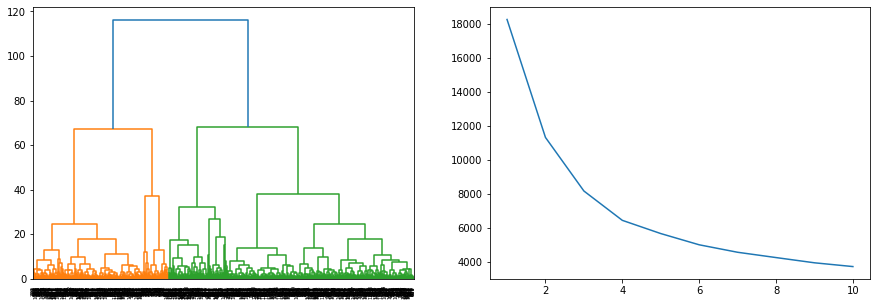

```python
recherche(0)
```

- Représentations identique, différence entre les 4 types de tracés venant du démarrage

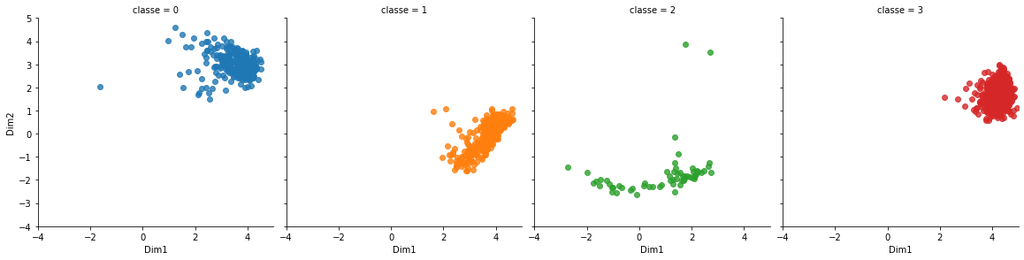

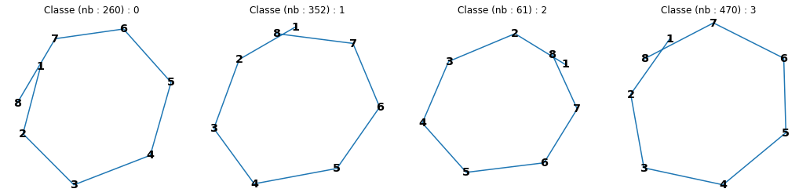

```python
application(0, 4)
```

## Chiffre 1

- On peut hésiter entre 2 et 4 classes

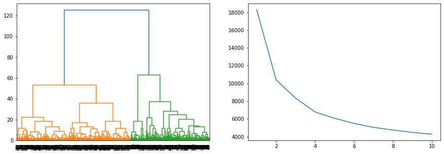

```python
recherche(1)
```

Avec 4 classes, on est plus fin sur les distinctions entre les types de tracé :

- deux classes ont un tracé similaire
- une classe concerne les tracés avec une barre en bas ;
- une concerne elle les tracés en un seul trait vertical.

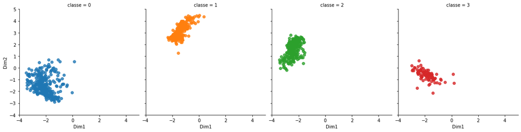

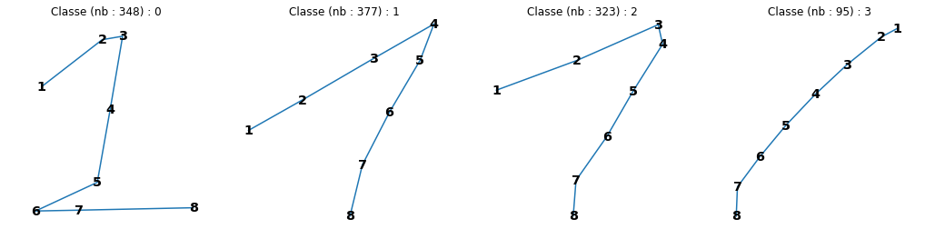

```python
application(1, 4)
```

## Chiffre 2

- Il ne semble pas vraiment y avoir plus d'une classe

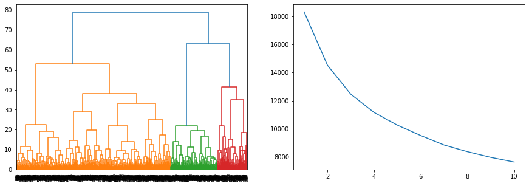

```python
recherche(2)
```

- En testant 2, 3 ou 4 classes (qui peuvent se justifier via la CAH), on remarque que les tracés moyens des classes sont tous identiques.

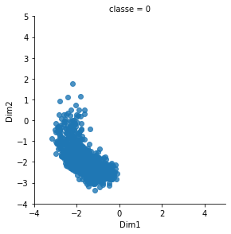

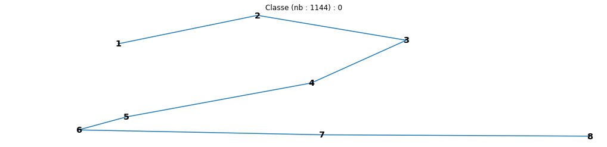

```python
application(2, 1)
```

## Chiffre 3

- Il ne semble pas vraiment y avoir plus d'une classe

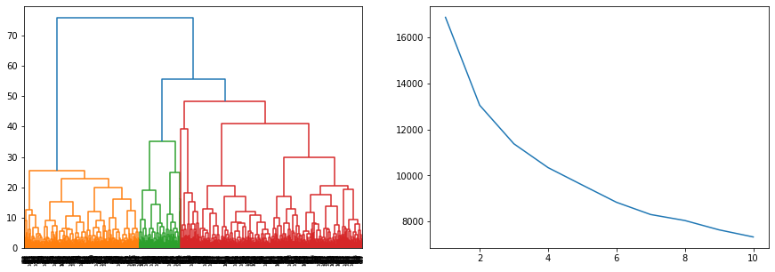

```python
recherche(3)
```

- En testant 2 classes (qui peut se justifier via la CAH), on remarque que les tracés moyens des 2 classes sont identiques.

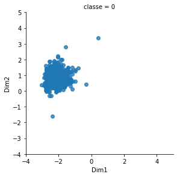

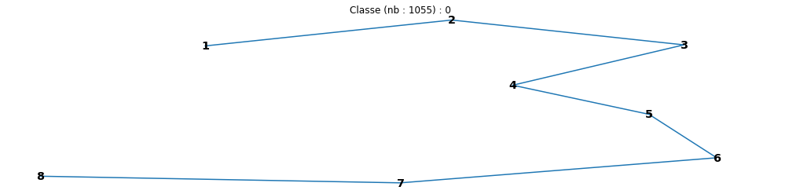

```python
application(3, 1)
```

## Chiffre 4

- Ici, seule une partition en 3 classes semble avoir du sens

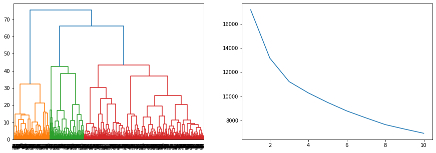

```python
recherche(4)
```

- Les tracés sont assez similaires et divergent entre eux principalement sur la deuxième partie du dessin.

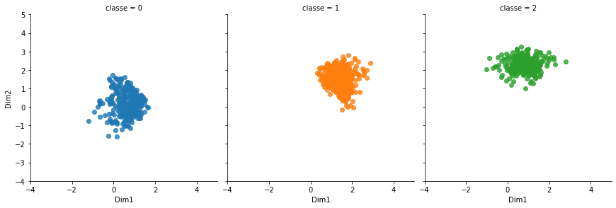

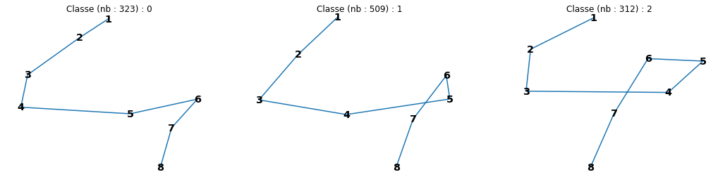

```python
application(4, 3)
```

## Chiffre 5

- Il semble assez clair qu'il y a 2 classes très différentes

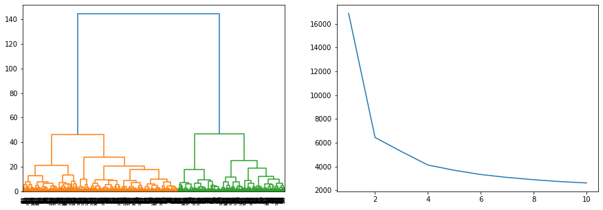

```python
recherche(5)
```

- Une classe concerne les tracés en un seul mouvement, l'autre concernant les tracés en 2 mouvements (avec soulèvement du stylo donc).

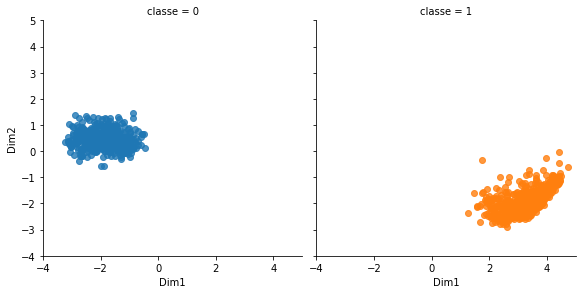

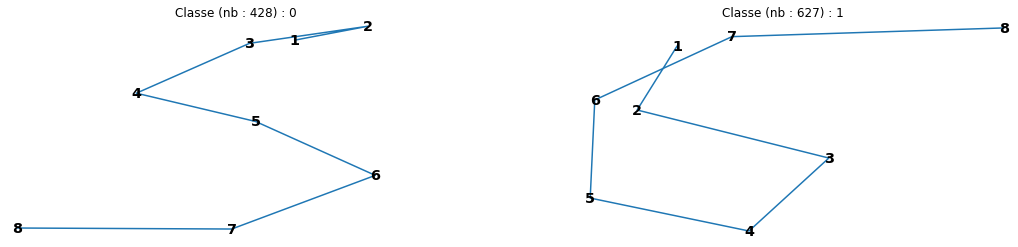

```python
application(5, 2)
```

## Chiffre 6

- Il ne semble pas vraiment y avoir plus d'une classe, même si la recherche tend à choisir 2 classes

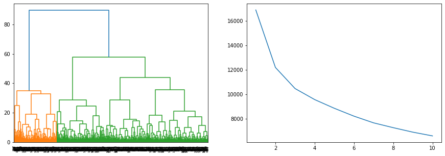

```python
recherche(6)
```

- Les 2 classes ont des tracés moyens quasiment identiques.

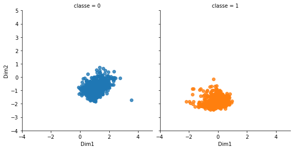

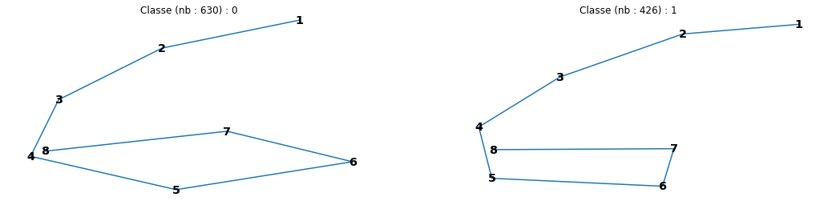

```python
application(6, 2)
```

## Chiffre 7

- On peut hésiter entre 2 et 3 classes

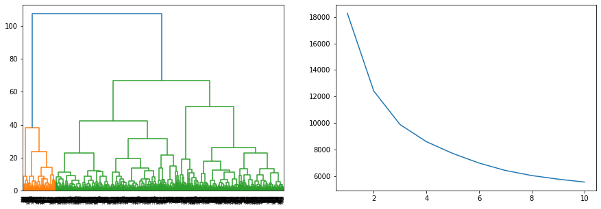

```python
recherche(7)
```

- La différence est flagrante entre les deux :
  - une classe majoritaire contient les tracés avec une barre au milieu ;
  - une classe minoritaire contient les tracés sans barre au milieu.

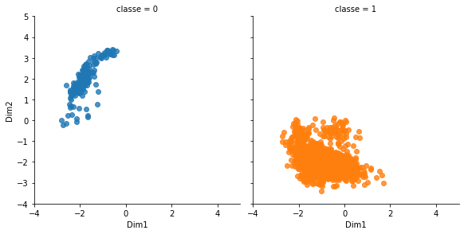

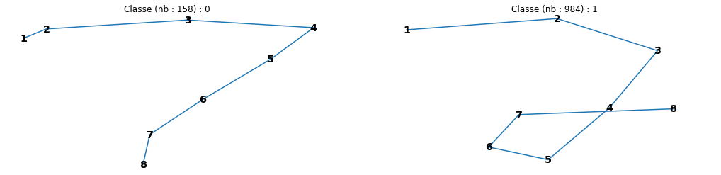

```python
application(7, 2)
```